# Data Exploration and Preparation (CA Group)

**Students:**  
2021411 Jose Fernando Gonzalez Anavia  
2022579 Mark Christian Bautista Albinto

**Lecturer:**  
Dr. Muhammad Iqbal

**Tasks a - d:** Mark Christian Bautista Albinto  
**Tasks e - h:** Jose Fernando Gonzalez Anavia

#### Citations:

Beata Strack, Jonathan P. DeShazo, Chris Gennings, Juan L. Olmo, Sebastian Ventura, Krzysztof J. Cios, and John N. Clore, “Impact of HbA1c Measurement on Hospital Readmission Rates: Analysis of 70,000 Clinical Database Patient Records,” BioMed Research International, vol. 2014, Article ID 781670, 11 pages, 2014.

**Remove all environment variables for new project**

```r
rm(list = ls())
```

**Import Libraries**

```r
library(dplyr)
library(ggplot2)
library(reshape)
```

#### Data Set Information:

**Dataset Source:** https://archive.ics.uci.edu/ml/datasets/Diabetes+130-US+hospitals+for+years+1999-2008#

The dataset represents 10 years (1999-2008) of clinical care at 130 US hospitals and integrated delivery networks. It includes over 50 features representing patient and hospital outcomes. Information was extracted from the database for encounters that satisfied the following criteria.

1. It is an inpatient encounter (a hospital admission).
2. It is a diabetic encounter, that is, one during which any kind of diabetes was entered to the system as a diagnosis.
3. The length of stay was at least 1 day and at most 14 days.
4. Laboratory tests were performed during the encounter.
5. Medications were administered during the encounter.

The data contains such attributes as patient number, race, gender, age, admission type, time in hospital, medical specialty of admitting physician, number of lab test performed, HbA1c test result, diagnosis, number of medication, diabetic medications, number of outpatient, inpatient, and emergency visits in the year before the hospitalization, etc.

#### Attribute Information:

Detailed description of all the atrributes is provided in Table 1 Beata Strack, Jonathan P. DeShazo, Chris Gennings, Juan L. Olmo, Sebastian Ventura, Krzysztof J. Cios, and John N. Clore, “Impact of HbA1c Measurement on Hospital Readmission Rates: Analysis of 70,000 Clinical Database Patient Records,” BioMed Research International, vol. 2014, Article ID 781670, 11 pages, 2014

https://www.hindawi.com/journals/bmri/2014/781670/

**Import Datasets**

```r
df <- read.csv('diabetic_data.csv')
id <- read.csv('IDs_mapping.csv')
```

Let’s take a look on what is inside the datasets

```r
str(df)
```

```
'data.frame':   101766 obs. of  50 variables:
 $ encounter_id            : int  2278392 149190 64410 500364 16680 35754 55842 63768 12522 15738 ...
 $ patient_nbr             : int  8222157 55629189 86047875 82442376 42519267 82637451 84259809 114882984 48330783 63555939 ...
 $ race                    : chr  "Caucasian" "Caucasian" "AfricanAmerican" "Caucasian" ...
 $ gender                  : chr  "Female" "Female" "Female" "Male" ...
 $ age                     : chr  "[0-10)" "[10-20)" "[20-30)" "[30-40)" ...
 $ weight                  : chr  "?" "?" "?" "?" ...
 $ admission_type_id       : int  6 1 1 1 1 2 3 1 2 3 ...
 $ discharge_disposition_id: int  25 1 1 1 1 1 1 1 1 3 ...
 $ admission_source_id     : int  1 7 7 7 7 2 2 7 4 4 ...
 $ time_in_hospital        : int  1 3 2 2 1 3 4 5 13 12 ...
 $ payer_code              : chr  "?" "?" "?" "?" ...
 $ medical_specialty       : chr  "Pediatrics-Endocrinology" "?" "?" "?" ...
 $ num_lab_procedures      : int  41 59 11 44 51 31 70 73 68 33 ...
 $ num_procedures          : int  0 0 5 1 0 6 1 0 2 3 ...
```

[output cut: 36 more lines]

The diabetes dataframe (df) contains 101766 observations of 50 variables

```r
str(id)
```

```
'data.frame':   67 obs. of  2 variables:
 $ admission_type_id: chr  "1" "2" "3" "4" ...
 $ description      : chr  "Emergency" "Urgent" "Elective" "Newborn" ...
```

The id dataframe contains 67 observations of 2 variables

```r
head(df)
```

|  | encounter_id | patient_nbr | race | gender | age | weight | admission_type_id | discharge_disposition_id | admission_source_id | time_in_hospital | payer_code | medical_specialty | num_lab_procedures | num_procedures | num_medications | number_outpatient | number_emergency | number_inpatient | diag_1 | diag_2 | diag_3 | number_diagnoses | max_glu_serum | A1Cresult | metformin | repaglinide | nateglinide | chlorpropamide | glimepiride | … |
| --- | --- | --- | --- | --- | --- | --- | --- | --- | --- | --- | --- | --- | --- | --- | --- | --- | --- | --- | --- | --- | --- | --- | --- | --- | --- | --- | --- | --- | --- | --- |
| 1 | 2278392 | 8222157 | Caucasian | Female | [0-10) | ? | 6 | 25 | 1 | 1 | ? | Pediatrics-Endocrinology | 41 | 0 | 1 | 0 | 0 | 0 | 250.83 | ? | ? | 1 | None | None | No | No | No | No | No | … |
| 2 | 149190 | 55629189 | Caucasian | Female | [10-20) | ? | 1 | 1 | 7 | 3 | ? | ? | 59 | 0 | 18 | 0 | 0 | 0 | 276 | 250.01 | 255 | 9 | None | None | No | No | No | No | No | … |
| 3 | 64410 | 86047875 | AfricanAmerican | Female | [20-30) | ? | 1 | 1 | 7 | 2 | ? | ? | 11 | 5 | 13 | 2 | 0 | 1 | 648 | 250 | V27 | 6 | None | None | No | No | No | No | No | … |
| 4 | 500364 | 82442376 | Caucasian | Male | [30-40) | ? | 1 | 1 | 7 | 2 | ? | ? | 44 | 1 | 16 | 0 | 0 | 0 | 8 | 250.43 | 403 | 7 | None | None | No | No | No | No | No | … |
| 5 | 16680 | 42519267 | Caucasian | Male | [40-50) | ? | 1 | 1 | 7 | 1 | ? | ? | 51 | 0 | 8 | 0 | 0 | 0 | 197 | 157 | 250 | 5 | None | None | No | No | No | No | No | … |
| 6 | 35754 | 82637451 | Caucasian | Male | [50-60) | ? | 2 | 1 | 2 | 3 | ? | ? | 31 | 6 | 16 | 0 | 0 | 0 | 414 | 411 | 250 | 9 | None | None | No | No | No | No | No | … |

```r
head(id)
```

|  | admission_type_id | description |
| --- | --- | --- |
| 1 | 1 | Emergency |
| 2 | 2 | Urgent |
| 3 | 3 | Elective |
| 4 | 4 | Newborn |
| 5 | 5 | Not Available |
| 6 | 6 | NULL |

## Assessment Tasks

#### a) Identify which variables are categorical, discrete and continuous in the chosen data set and show using some visualization or plot. Explore whether there are missing values for any of the variables.

First let’s take a closer look at the id dataframe

```r
id
```

| admission_type_id | description |
| --- | --- |
| 1 | Emergency |
| 2 | Urgent |
| 3 | Elective |
| 4 | Newborn |
| 5 | Not Available |
| 6 | NULL |
| 7 | Trauma Center |
| 8 | Not Mapped |
| discharge_disposition_id | description |

[output cut: 57 more lines]

As we can see, the ID variables are interchanged to all other ids so we will separate them to each of their own dataframes

#### Clean up id dataframe

First let’s find out what is the maximum number(id) from the id dataframe

```r
num_only_temp <- as.numeric(id$admission_type_id)
max(na.omit(num_only_temp))
```

```
[1] 30
```

**Extract data to each of their corresponding dataframe**

method:

1. create an new dataframes (id_{type}) to push data to as we clean up the id dataframe
2. Separate values to corresponding dataframe

```r
# create new dataframe for admission_type
admission_type <- data.frame(id[1:8, ])
colnames(admission_type)[1] = "id"
admission_type
```

|  | id | description |
| --- | --- | --- |
| 1 | 1 | Emergency |
| 2 | 2 | Urgent |
| 3 | 3 | Elective |
| 4 | 4 | Newborn |
| 5 | 5 | Not Available |
| 6 | 6 | NULL |
| 7 | 7 | Trauma Center |
| 8 | 8 | Not Mapped |

```r
# create new dataframe for discharge_disposition
discharge_disposition <- data.frame(id[11:40, ])
colnames(discharge_disposition)[1] = "id"
discharge_disposition
```

|  | id | description |
| --- | --- | --- |
| 11 | 1 | Discharged to home |
| 12 | 2 | Discharged/transferred to another short term hospital |
| 13 | 3 | Discharged/transferred to SNF |
| 14 | 4 | Discharged/transferred to ICF |
| 15 | 5 | Discharged/transferred to another type of inpatient care institution |
| 16 | 6 | Discharged/transferred to home with home health service |
| 17 | 7 | Left AMA |
| 18 | 8 | Discharged/transferred to home under care of Home IV provider |
| 19 | 9 | Admitted as an inpatient to this hospital |
| 20 | 10 | Neonate discharged to another hospital for neonatal aftercare |

[output cut: 20 more lines]

```r
# create new dataframe for discharge_disposition
admission_source <- data.frame(id[43:67, ])
colnames(admission_source)[1] = "id"
admission_source
```

|  | id | description |
| --- | --- | --- |
| 43 | 1 | Physician Referral |
| 44 | 2 | Clinic Referral |
| 45 | 3 | HMO Referral |
| 46 | 4 | Transfer from a hospital |
| 47 | 5 | Transfer from a Skilled Nursing Facility (SNF) |
| 48 | 6 | Transfer from another health care facility |
| 49 | 7 | Emergency Room |
| 50 | 8 | Court/Law Enforcement |
| 51 | 9 | Not Available |
| 52 | 10 | Transfer from critial access hospital |

[output cut: 15 more lines]

All of the variables are categorical variables excluding the id which is sequential and is used to reference values from df dataframe

Some values are missing and some use different terms like: Not Available, NA, NULL, Not Mapped, Unknown/Invalid

**Next let’s take a look at the diabetes(df) dataframe**

```r
df
```

| encounter_id | patient_nbr | race | gender | age | weight | admission_type_id | discharge_disposition_id | admission_source_id | time_in_hospital | payer_code | medical_specialty | num_lab_procedures | num_procedures | num_medications | number_outpatient | number_emergency | number_inpatient | diag_1 | diag_2 | diag_3 | number_diagnoses | max_glu_serum | A1Cresult | metformin | repaglinide | nateglinide | chlorpropamide | glimepiride | acetohexamide | … |
| --- | --- | --- | --- | --- | --- | --- | --- | --- | --- | --- | --- | --- | --- | --- | --- | --- | --- | --- | --- | --- | --- | --- | --- | --- | --- | --- | --- | --- | --- | --- |
| 2278392 | 8222157 | Caucasian | Female | [0-10) | ? | 6 | 25 | 1 | 1 | ? | Pediatrics-Endocrinology | 41 | 0 | 1 | 0 | 0 | 0 | 250.83 | ? | ? | 1 | None | None | No | No | No | No | No | No | … |
| 149190 | 55629189 | Caucasian | Female | [10-20) | ? | 1 | 1 | 7 | 3 | ? | ? | 59 | 0 | 18 | 0 | 0 | 0 | 276 | 250.01 | 255 | 9 | None | None | No | No | No | No | No | No | … |
| 64410 | 86047875 | AfricanAmerican | Female | [20-30) | ? | 1 | 1 | 7 | 2 | ? | ? | 11 | 5 | 13 | 2 | 0 | 1 | 648 | 250 | V27 | 6 | None | None | No | No | No | No | No | No | … |
| 500364 | 82442376 | Caucasian | Male | [30-40) | ? | 1 | 1 | 7 | 2 | ? | ? | 44 | 1 | 16 | 0 | 0 | 0 | 8 | 250.43 | 403 | 7 | None | None | No | No | No | No | No | No | … |
| 16680 | 42519267 | Caucasian | Male | [40-50) | ? | 1 | 1 | 7 | 1 | ? | ? | 51 | 0 | 8 | 0 | 0 | 0 | 197 | 157 | 250 | 5 | None | None | No | No | No | No | No | No | … |
| 35754 | 82637451 | Caucasian | Male | [50-60) | ? | 2 | 1 | 2 | 3 | ? | ? | 31 | 6 | 16 | 0 | 0 | 0 | 414 | 411 | 250 | 9 | None | None | No | No | No | No | No | No | … |
| 55842 | 84259809 | Caucasian | Male | [60-70) | ? | 3 | 1 | 2 | 4 | ? | ? | 70 | 1 | 21 | 0 | 0 | 0 | 414 | 411 | V45 | 7 | None | None | Steady | No | No | No | Steady | No | … |
| 63768 | 114882984 | Caucasian | Male | [70-80) | ? | 1 | 1 | 7 | 5 | ? | ? | 73 | 0 | 12 | 0 | 0 | 0 | 428 | 492 | 250 | 8 | None | None | No | No | No | No | No | No | … |
| 12522 | 48330783 | Caucasian | Female | [80-90) | ? | 2 | 1 | 4 | 13 | ? | ? | 68 | 2 | 28 | 0 | 0 | 0 | 398 | 427 | 38 | 8 | None | None | No | No | No | No | No | No | … |
| 15738 | 63555939 | Caucasian | Female | [90-100) | ? | 3 | 3 | 4 | 12 | ? | InternalMedicine | 33 | 3 | 18 | 0 | 0 | 0 | 434 | 198 | 486 | 8 | None | None | No | No | No | No | No | No | … |

[output cut: 990 more lines]

It seems that the diabetes(df) dataframe uses ? as NA but we will check NA values anyway just to make sure

```r
na_count <- sapply(df, function(y) sum(length(which(is.na(y)))))
na_count
```

```
            encounter_id              patient_nbr                     race
                       0                        0                        0
                  gender                      age                   weight
                       0                        0                        0
       admission_type_id discharge_disposition_id      admission_source_id
                       0                        0                        0
        time_in_hospital               payer_code        medical_specialty
                       0                        0                        0
      num_lab_procedures           num_procedures          num_medications
                       0                        0                        0
       number_outpatient         number_emergency         number_inpatient
                       0                        0                        0
                  diag_1                   diag_2                   diag_3
                       0                        0                        0
        number_diagnoses            max_glu_serum                A1Cresult
                       0                        0                        0
               metformin              repaglinide              nateglinide
                       0                        0                        0
          chlorpropamide              glimepiride            acetohexamide
                       0                        0                        0
               glipizide                glyburide              tolbutamide
                       0                        0                        0
            pioglitazone            rosiglitazone                 acarbose
                       0                        0                        0
                miglitol             troglitazone               tolazamide
                       0                        0                        0
                 examide              citoglipton                  insulin
                       0                        0                        0
     glyburide.metformin      glipizide.metformin glimepiride.pioglitazone
                       0                        0                        0
 metformin.rosiglitazone   metformin.pioglitazone                   change
                       0                        0                        0
             diabetesMed               readmitted
                       0                        0
```

There is no NA values in the dataframe as expected

```r
na_count_question <- sapply(df, function(y) sum(length(which(y == '?'))))
na_count_question
```

```
            encounter_id              patient_nbr                     race
                       0                        0                     2273
                  gender                      age                   weight
                       0                        0                    98569
       admission_type_id discharge_disposition_id      admission_source_id
                       0                        0                        0
        time_in_hospital               payer_code        medical_specialty
                       0                    40256                    49949
      num_lab_procedures           num_procedures          num_medications
                       0                        0                        0
       number_outpatient         number_emergency         number_inpatient
                       0                        0                        0
                  diag_1                   diag_2                   diag_3
                      21                      358                     1423
        number_diagnoses            max_glu_serum                A1Cresult
                       0                        0                        0
               metformin              repaglinide              nateglinide
                       0                        0                        0
          chlorpropamide              glimepiride            acetohexamide
                       0                        0                        0
               glipizide                glyburide              tolbutamide
                       0                        0                        0
            pioglitazone            rosiglitazone                 acarbose
                       0                        0                        0
                miglitol             troglitazone               tolazamide
                       0                        0                        0
                 examide              citoglipton                  insulin
                       0                        0                        0
     glyburide.metformin      glipizide.metformin glimepiride.pioglitazone
                       0                        0                        0
 metformin.rosiglitazone   metformin.pioglitazone                   change
                       0                        0                        0
             diabetesMed               readmitted
                       0                        0
```

As we can see, columns weight, medical_specialty and payer_code has a lot of missing values so it is safe to omit those columns as they wouldn’t helpful for the analysis

```r
df
```

| encounter_id | patient_nbr | race | gender | age | weight | admission_type_id | discharge_disposition_id | admission_source_id | time_in_hospital | payer_code | medical_specialty | num_lab_procedures | num_procedures | num_medications | number_outpatient | number_emergency | number_inpatient | diag_1 | diag_2 | diag_3 | number_diagnoses | max_glu_serum | A1Cresult | metformin | repaglinide | nateglinide | chlorpropamide | glimepiride | acetohexamide | … |
| --- | --- | --- | --- | --- | --- | --- | --- | --- | --- | --- | --- | --- | --- | --- | --- | --- | --- | --- | --- | --- | --- | --- | --- | --- | --- | --- | --- | --- | --- | --- |
| 2278392 | 8222157 | Caucasian | Female | [0-10) | ? | 6 | 25 | 1 | 1 | ? | Pediatrics-Endocrinology | 41 | 0 | 1 | 0 | 0 | 0 | 250.83 | ? | ? | 1 | None | None | No | No | No | No | No | No | … |
| 149190 | 55629189 | Caucasian | Female | [10-20) | ? | 1 | 1 | 7 | 3 | ? | ? | 59 | 0 | 18 | 0 | 0 | 0 | 276 | 250.01 | 255 | 9 | None | None | No | No | No | No | No | No | … |
| 64410 | 86047875 | AfricanAmerican | Female | [20-30) | ? | 1 | 1 | 7 | 2 | ? | ? | 11 | 5 | 13 | 2 | 0 | 1 | 648 | 250 | V27 | 6 | None | None | No | No | No | No | No | No | … |
| 500364 | 82442376 | Caucasian | Male | [30-40) | ? | 1 | 1 | 7 | 2 | ? | ? | 44 | 1 | 16 | 0 | 0 | 0 | 8 | 250.43 | 403 | 7 | None | None | No | No | No | No | No | No | … |
| 16680 | 42519267 | Caucasian | Male | [40-50) | ? | 1 | 1 | 7 | 1 | ? | ? | 51 | 0 | 8 | 0 | 0 | 0 | 197 | 157 | 250 | 5 | None | None | No | No | No | No | No | No | … |
| 35754 | 82637451 | Caucasian | Male | [50-60) | ? | 2 | 1 | 2 | 3 | ? | ? | 31 | 6 | 16 | 0 | 0 | 0 | 414 | 411 | 250 | 9 | None | None | No | No | No | No | No | No | … |
| 55842 | 84259809 | Caucasian | Male | [60-70) | ? | 3 | 1 | 2 | 4 | ? | ? | 70 | 1 | 21 | 0 | 0 | 0 | 414 | 411 | V45 | 7 | None | None | Steady | No | No | No | Steady | No | … |
| 63768 | 114882984 | Caucasian | Male | [70-80) | ? | 1 | 1 | 7 | 5 | ? | ? | 73 | 0 | 12 | 0 | 0 | 0 | 428 | 492 | 250 | 8 | None | None | No | No | No | No | No | No | … |
| 12522 | 48330783 | Caucasian | Female | [80-90) | ? | 2 | 1 | 4 | 13 | ? | ? | 68 | 2 | 28 | 0 | 0 | 0 | 398 | 427 | 38 | 8 | None | None | No | No | No | No | No | No | … |
| 15738 | 63555939 | Caucasian | Female | [90-100) | ? | 3 | 3 | 4 | 12 | ? | InternalMedicine | 33 | 3 | 18 | 0 | 0 | 0 | 434 | 198 | 486 | 8 | None | None | No | No | No | No | No | No | … |

[output cut: 990 more lines]

identifiers: encounter_id, patient_nbr

categorical: race, gender, admission_type_id, discharge_position_id, admission_source_id, medical specialty, max_glu_serum, A1Cresult, metformin, repaglinide, nateglinide, chlorpropamide, glimepiride, acetohexamide, glipizide, glyburide, tolbutamide, pioglitazone, rosiglitazone, acarbose, miglitol, troglitazone, tolazamide, examide, citoglipton, insulin, glyburide.metformin, glipizide.metformin, glimepiride.pioglitazone, metformin.rosiglitazone, metformin.pioglitazone, change, diabetesMed, readmitted

admission_type_id, discharge_position_id, admission_source_id references values to id dataframe so it is treated as a categorical data

discrete: age, time_in_hospital, num_lab_procedures, num_procedures, num_medications, number_outpatient, ,number_emergency,number_inpatient, diag_1, diag_2, diag_3, number_diagnoses

age in medical data is treated as discrete data but the way the values are represented suggests that it can be treated as categorical data

continuous:

unfortunately, we didn’t find any variable that has continuous data

#### Clean up diabetes(df) dataframe

Since the project requires only 10,000 rows, we will omit some rows with ? values and create a sample with only 10,000 rows

First, let’s omit columns weight, medical_specialty, payer_code as they have too much missing value

```r
df[ ,c('weight', 'medical_specialty', 'payer_code')] <- list(NULL)
head(df)
```

|  | encounter_id | patient_nbr | race | gender | age | admission_type_id | discharge_disposition_id | admission_source_id | time_in_hospital | num_lab_procedures | num_procedures | num_medications | number_outpatient | number_emergency | number_inpatient | diag_1 | diag_2 | diag_3 | number_diagnoses | max_glu_serum | A1Cresult | metformin | repaglinide | nateglinide | chlorpropamide | glimepiride | acetohexamide | glipizide | glyburide | … |
| --- | --- | --- | --- | --- | --- | --- | --- | --- | --- | --- | --- | --- | --- | --- | --- | --- | --- | --- | --- | --- | --- | --- | --- | --- | --- | --- | --- | --- | --- | --- |
| 1 | 2278392 | 8222157 | Caucasian | Female | [0-10) | 6 | 25 | 1 | 1 | 41 | 0 | 1 | 0 | 0 | 0 | 250.83 | ? | ? | 1 | None | None | No | No | No | No | No | No | No | No | … |
| 2 | 149190 | 55629189 | Caucasian | Female | [10-20) | 1 | 1 | 7 | 3 | 59 | 0 | 18 | 0 | 0 | 0 | 276 | 250.01 | 255 | 9 | None | None | No | No | No | No | No | No | No | No | … |
| 3 | 64410 | 86047875 | AfricanAmerican | Female | [20-30) | 1 | 1 | 7 | 2 | 11 | 5 | 13 | 2 | 0 | 1 | 648 | 250 | V27 | 6 | None | None | No | No | No | No | No | No | Steady | No | … |
| 4 | 500364 | 82442376 | Caucasian | Male | [30-40) | 1 | 1 | 7 | 2 | 44 | 1 | 16 | 0 | 0 | 0 | 8 | 250.43 | 403 | 7 | None | None | No | No | No | No | No | No | No | No | … |
| 5 | 16680 | 42519267 | Caucasian | Male | [40-50) | 1 | 1 | 7 | 1 | 51 | 0 | 8 | 0 | 0 | 0 | 197 | 157 | 250 | 5 | None | None | No | No | No | No | No | No | Steady | No | … |
| 6 | 35754 | 82637451 | Caucasian | Male | [50-60) | 2 | 1 | 2 | 3 | 31 | 6 | 16 | 0 | 0 | 0 | 414 | 411 | 250 | 9 | None | None | No | No | No | No | No | No | No | No | … |

**Next we are going to remove rows with ? values**

method: use for loop to loop through all the columns and filter the rows that does not contain ?

```r
for(i in 1:ncol(df)) {
  df <- df[!(df[, i] == "?"), ]
}

nrow(df)
```

```
[1] 98053
```

From 101,766 observations to 98,053 observations after omitting all rows with ? values

Now that we omitted all the rown with ? values we can take a sample of 10,000 values to proceed through the analysis using sample_n function from package dplyr

But before doing that, we need to set the seed first for us to get the same sequence of samples

```r
set.seed(5555)
df_clean <- sample_n(df, 10000)
nrow(df_clean)
```

```
[1] 10000
```

**Plotting categorical variables (number of cases by race separated by gender and color categorized by age)**

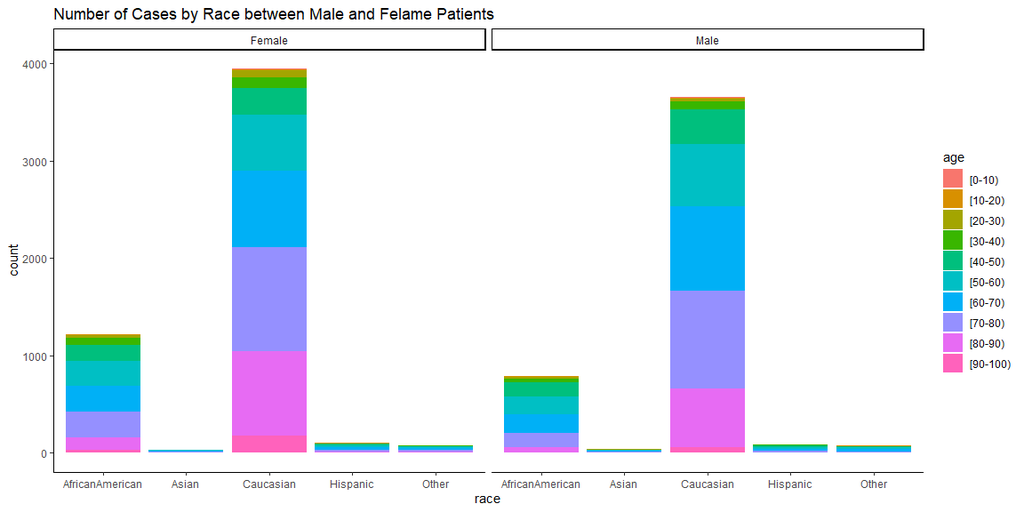

```r
ggplot(data = df_clean) +
  geom_bar(aes(x = race, fill = age)) +
  facet_wrap(~gender) +
  ggtitle('Number of Cases by Race between Male and Felame Patients') +
  theme_classic()
```

#### b) Calculate the statistical parameters (mean, median, minimum, maximum, and standard deviation) for each of the numerical variables

**Extract all numerical variables to a new dataframe**

```r
df_numerical <- df_clean[, c('time_in_hospital', 'num_lab_procedures', 'num_procedures',  'num_medications', 'number_outpatient', 'number_emergency',  'number_inpatient', 'number_diagnoses')]
```

**Getting the statistical parameters of the numerical variables using functions summary and sd**

```r
for(i in 1:ncol(df_numerical)){
  print(names(df_numerical[i]))
  print(summary(df_numerical[, i]))
  print('Standard Deviation')
  print(sd(df_numerical[, i]))
  print('-------------------------------------')
}
```

```
[1] "time_in_hospital"
   Min. 1st Qu.  Median    Mean 3rd Qu.    Max.
  1.000   2.000   4.000   4.394   6.000  14.000
[1] "Standard Deviation"
[1] 2.974792
[1] "-------------------------------------"
[1] "num_lab_procedures"
   Min. 1st Qu.  Median    Mean 3rd Qu.    Max.
   1.00   32.00   44.00   43.31   57.00  114.00
[1] "Standard Deviation"
[1] 19.49462
[1] "-------------------------------------"
[1] "num_procedures"
   Min. 1st Qu.  Median    Mean 3rd Qu.    Max.
  0.000   0.000   1.000   1.347   2.000   6.000
[1] "Standard Deviation"
[1] 1.716519
[1] "-------------------------------------"
[1] "num_medications"
   Min. 1st Qu.  Median    Mean 3rd Qu.    Max.
    1.0    10.0    15.0    16.1    20.0    75.0
[1] "Standard Deviation"
[1] 8.018278
[1] "-------------------------------------"
[1] "number_outpatient"
   Min. 1st Qu.  Median    Mean 3rd Qu.    Max.
 0.0000  0.0000  0.0000  0.3826  0.0000 35.0000
[1] "Standard Deviation"
[1] 1.378698
[1] "-------------------------------------"
[1] "number_emergency"
   Min. 1st Qu.  Median    Mean 3rd Qu.    Max.
 0.0000  0.0000  0.0000  0.2049  0.0000 25.0000
[1] "Standard Deviation"
[1] 0.8185249
[1] "-------------------------------------"
[1] "number_inpatient"
   Min. 1st Qu.  Median    Mean 3rd Qu.    Max.
   0.00    0.00    0.00    0.66    1.00   21.00
[1] "Standard Deviation"
[1] 1.298217
[1] "-------------------------------------"
[1] "number_diagnoses"
   Min. 1st Qu.  Median    Mean 3rd Qu.    Max.
  3.000   6.000   8.000   7.506   9.000  16.000
[1] "Standard Deviation"
[1] 1.83344
[1] "-------------------------------------"
```

**Plotting statistical parameters using boxplot**

Creating multiple boxplots using different variables can be quite difficult and messy with the code so we will first melt the data to get only 2 columns using their column as a name and their row as a value.

```r
df_numerical_melted <- melt(df_numerical)
```

```
Using  as id variables
```

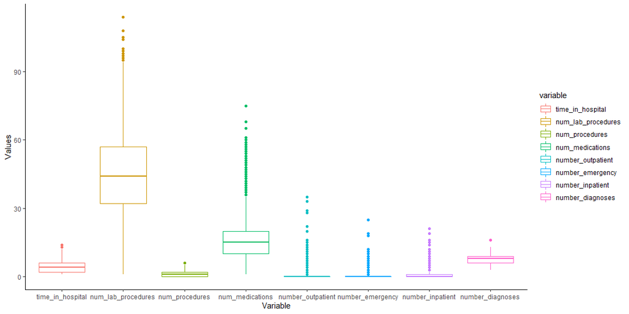

```r
ggplot(df_numerical_melted, aes(factor(variable), value, color = variable)) +
  geom_boxplot() +
  labs(x = 'Variable', y = 'Values') +
  theme_classic()
```

#### c) Apply Min-Max Normalization, Z-score Standardization and Robust scalar on the numerical data variables.

**Applying Min-Max Normalization using formula x* = (x - min(x) / (max(x) - min(x)))**

**First let us create the function to normalize the data**

```r
mm_norm <- function(x){
  return ((x - min(x)) / (max(x) - min(x)))
}
```

**Next let us take a look at the initial values before normalization (we are going to use num_procedures and num_medications variables)**

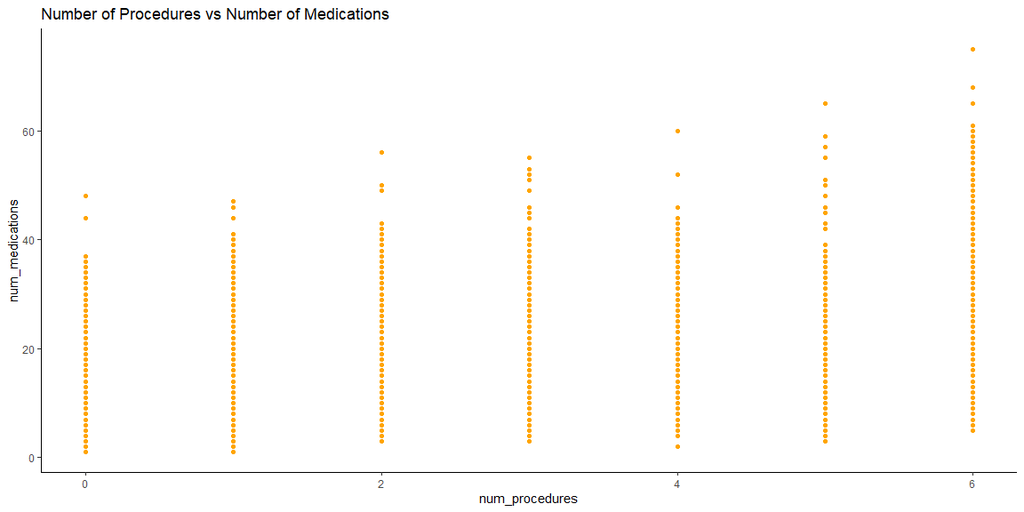

```r
ggplot(df_numerical, aes(x = num_procedures, y = num_medications)) +
  geom_point(colour = 'orange') +
  ggtitle('Number of Procedures vs Number of Medications') +
  theme_classic()
```

The initial range of the plot is from 0 - 80

Since we already created a subset for the numerical variables (df_numerical), we can use that subset to simplify the normalization

```r
names(df_numerical)
```

```
[1] "time_in_hospital"   "num_lab_procedures" "num_procedures"     "num_medications"
[5] "number_outpatient"  "number_emergency"   "number_inpatient"   "number_diagnoses"
```

**Applying min-max normalization to all numerical variables**

```r
df_numerical$time_in_hospital_minmax <- mm_norm(df_numerical$time_in_hospital)
df_numerical$num_lab_procedures_minmax <- mm_norm(df_numerical$num_lab_procedures)
df_numerical$num_procedures_minmax <- mm_norm(df_numerical$num_procedures)
df_numerical$num_medications_minmax <- mm_norm(df_numerical$num_medications)
df_numerical$number_outpatient_minmax <- mm_norm(df_numerical$number_outpatient)
df_numerical$number_emergency_minmax <- mm_norm(df_numerical$number_emergency)
df_numerical$number_inpatient_minmax <- mm_norm(df_numerical$number_inpatient)
df_numerical$number_diagnoses_minmax <- mm_norm(df_numerical$number_diagnoses)
```

**Plot demonstration of normalized variables**

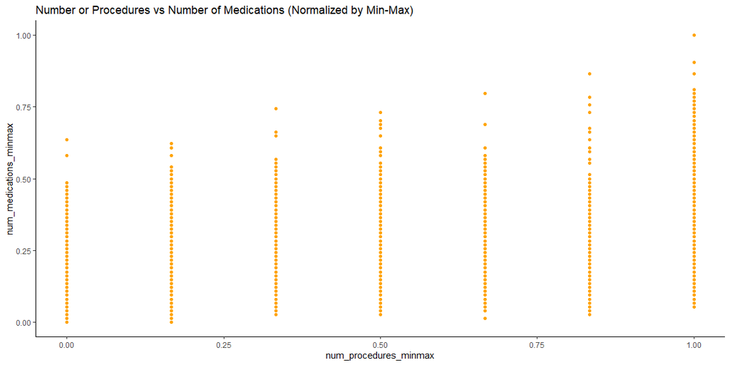

```r
ggplot(df_numerical, aes(x = num_procedures_minmax, y = num_medications_minmax)) +
  geom_point(colour = 'orange') +
  ggtitle('Number or Procedures vs Number of Medications (Normalized by Min-Max)') +
  theme_classic()
```

Min-Max Normalization Successful!

As we can see from the plot, there is only a low positive correlation between the variables. Meaning, as the number of procedures rise, the number of medications rise as well but only by a small margin.

**Applying Z-Score Standardization to all numerical variables using formula x* = ((x - mean(x)) / (sd(x)))**

```r
names(df_numerical)
```

```
 [1] "time_in_hospital"          "num_lab_procedures"        "num_procedures"
 [4] "num_medications"           "number_outpatient"         "number_emergency"
 [7] "number_inpatient"          "number_diagnoses"          "time_in_hospital_minmax"
[10] "num_lab_procedures_minmax" "num_procedures_minmax"     "num_medications_minmax"
[13] "number_outpatient_minmax"  "number_emergency_minmax"   "number_inpatient_minmax"
[16] "number_diagnoses_minmax"
```

**Applying Z-Score Standardization to all numerical variables**

```r
df_numerical$time_in_hospital_zscore <- scale(df_numerical$time_in_hospital)
df_numerical$num_lab_procedures_zscore <- scale(df_numerical$num_lab_procedures)
df_numerical$num_procedures_zscore <- scale(df_numerical$num_procedures)
df_numerical$num_medications_zscore <- scale(df_numerical$num_medications)
df_numerical$number_outpatient_zscore <- scale(df_numerical$number_outpatient)
df_numerical$number_emergency_zscore <- scale(df_numerical$number_emergency)
df_numerical$number_inpatient_zscore <- scale(df_numerical$number_inpatient)
df_numerical$number_diagnoses_zscore <- scale(df_numerical$number_diagnoses)
```

**Plot demonstration of normalized variables**

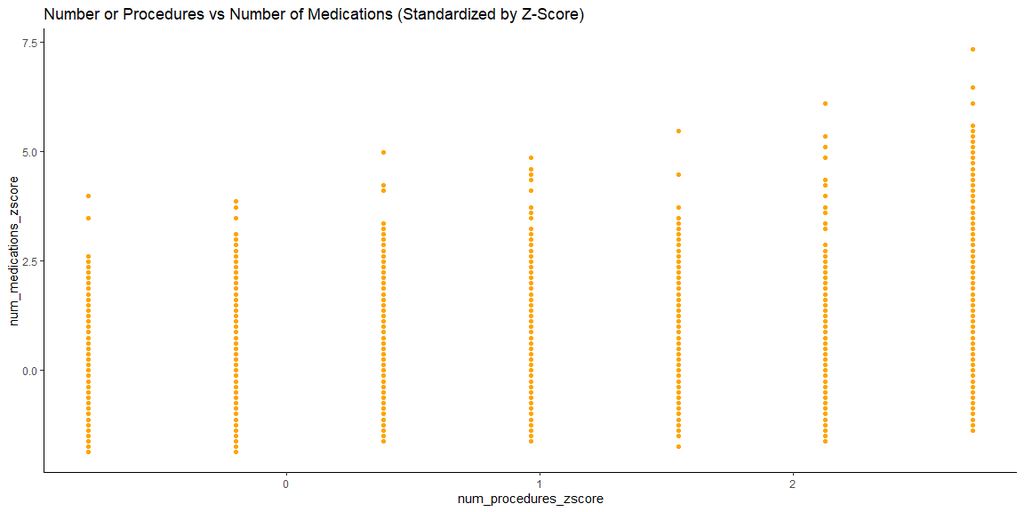

```r
ggplot(df_numerical, aes(x = num_procedures_zscore, y = num_medications_zscore)) +
  geom_point(colour = 'orange') +
  ggtitle('Number or Procedures vs Number of Medications (Standardized by Z-Score)') +
  theme_classic()
```

**First let us create the function to normalize the data**

```r
robust_scaler <- function(x){
  return ((x - median(x)) / (quantile(x, probs = 0.75) - quantile(x, probs = 0.25)))
}
```

```r
names(df_numerical)
```

```
 [1] "time_in_hospital"          "num_lab_procedures"        "num_procedures"
 [4] "num_medications"           "number_outpatient"         "number_emergency"
 [7] "number_inpatient"          "number_diagnoses"          "time_in_hospital_minmax"
[10] "num_lab_procedures_minmax" "num_procedures_minmax"     "num_medications_minmax"
[13] "number_outpatient_minmax"  "number_emergency_minmax"   "number_inpatient_minmax"
[16] "number_diagnoses_minmax"   "time_in_hospital_zscore"   "num_lab_procedures_zscore"
[19] "num_procedures_zscore"     "num_medications_zscore"    "number_outpatient_zscore"
[22] "number_emergency_zscore"   "number_inpatient_zscore"   "number_diagnoses_zscore"
```

```r
df_numerical$time_in_hospital_rscaler <- scale(df_numerical$time_in_hospital)
df_numerical$num_lab_procedures_rscaler <- scale(df_numerical$num_lab_procedures)
df_numerical$num_procedures_rscaler <- scale(df_numerical$num_procedures)
df_numerical$num_medications_rscaler <- scale(df_numerical$num_medications)
df_numerical$number_outpatient_rscaler <- scale(df_numerical$number_outpatient)
df_numerical$number_emergency_rscaler <- scale(df_numerical$number_emergency)
df_numerical$number_inpatient_rscaler <- scale(df_numerical$number_inpatient)
df_numerical$number_diagnoses_rscaler <- scale(df_numerical$number_diagnoses)
```

**Plot demonstration of normalized variables**

[figure not shown]

```r
ggplot(df_numerical, aes(num_procedures_rscaler)) +
  geom_boxplot(colour = 'orange') +
  ggtitle('Number or Procedures (Robust Scaler)') +
  theme_classic()
```

#### d) Line, Scatter and Heatmaps can be used to show the correlation between the features of the dataset.

**Preparing data**

Method:

1. Using the cor function returns a matrix of correlation between numerical variables.
2. Melt the correlation matrix to be plotted as count

```r
num_df <- df_clean[, c('time_in_hospital', 'num_lab_procedures', 'num_procedures',  'num_medications', 'number_outpatient', 'number_emergency',  'number_inpatient', 'number_diagnoses')]
num_cor <- cor(num_df)

num_cor_melted <- melt(num_cor)
```

**Plotting the correlation between numerical variables**

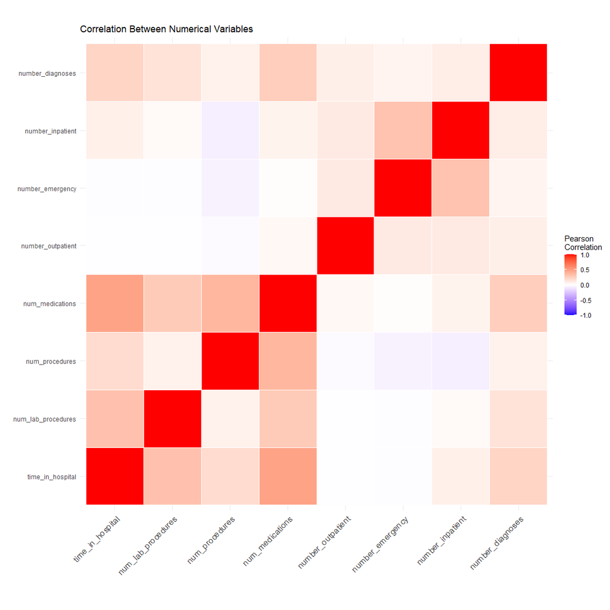

```r
ggplot(num_cor_melted, aes(x = X1, y = X2, fill = value)) +
  geom_tile(color = "white") +
  scale_fill_gradient2(
    low = "blue",
    high = "red",
    mid = "white",
    midpoint = 0,
    limit = c(-1, 1),
    space = "Lab",
    name = "Pearson\nCorrelation"
  ) +
  theme_minimal() +
  theme(axis.text.x = element_text(
    angle = 45,
    vjust = 1,
    size = 12,
    hjust = 1
  )) +
  coord_fixed() +
  xlab('') +
  ylab('') +
  ggtitle('Correlation Between Numerical Variables')
```